# L2 Penalty

**J. Taroni 2018**

We’ve been asked to clarify why an L2 penalty is used on the PLIER `B` matrix.

We’ll see what happens *in practice* if we set the `L2` parameter to zero.

Let’s work with the data that are 500 randomly selected samples from recount2; this is out of convenience, as the computational requirements will be relatively light.

The main PLIER function, for the version of PLIER we’ve used, begins here: https://github.com/wgmao/PLIER/blob/a2d4a2aa343f9ed4b9b945c04326bebd31533d4d/R/Allfuncs.R#L227

## Set up

```r
`%>%` <- dplyr::`%>%`
library(PLIER)
```

We’ll need `GetPathwayCoverage`

```r
source(file.path("util", "plier_util.R"))
```

#### Directories

Plot and results directories specifically for this notebook.

```r
# plot and result directory setup for this notebook
plot.dir <- file.path("plots", "39")
dir.create(plot.dir, recursive = TRUE, showWarnings = FALSE)
results.dir <- file.path("results", "39")
dir.create(results.dir, recursive = TRUE, showWarnings = FALSE)
```

## Read in data

Working only with `n = 500` here.

```r
models.file <- file.path("models", "subsampled_recount2_PLIER_model_500.RDS")
models.list <- readRDS(models.file)
```

Get the prior information matrix used with the subsampling experiments.

```r
recount.prepped.data <- readRDS(file.path("data", "recount2_PLIER_data",
                                          "recount_data_prep_PLIER.RDS"))
pathway.mat <- recount.prepped.data$all.paths.cm
rm(recount.prepped.data)
```

## Main

What constants were used originally (calculated from SVD)?

```r
lapply(models.list, function(x) x$PLIER$L1)
```

```
$`2876`
[1] 77.02955

$`7883`
[1] 75.08367

$`4089`
[1] 79.52204

$`8828`
[1] 66.83478

$`9401`
[1] 82.35129
```

```r
lapply(models.list, function(x) x$PLIER$L2)
```

```
$`2876`
[1] 154.0591

$`7883`
[1] 150.1673

$`4089`
[1] 159.0441

$`8828`
[1] 133.6696

$`9401`
[1] 164.7026
```

These are the automatically selected values.

### Training with `L2 = 0`

A custom function for setting L2 to zero.

```r
# plier.repeat is a list with the elements exprs (a gene expression matrix) and
# PLIER (output of PLIER); it is a repeat from script/subsampling_PLIER.R.
# use PLIER results as input to a new PLIER model, where we use the k, L1,
# priorMat, and expression from a repeat, BUT set L2 = 0
# only intended to be used in this environment (need pathway.)
SetL2Zero <- function(plier.repeat) {
  results <- PLIER::PLIER(data = as.matrix(plier.repeat$exprs),
                          priorMat = pathway.mat,
                          k = nrow(plier.repeat$PLIER$B),
                          L1 = plier.repeat$PLIER$L1,
                          L2 = 0,
                          trace = TRUE)
  message("\n\n")
  return(results)
}
```

Perform the training and save the results to file (they will be small enough to track with Git LFS).

```r
penalty.zero.list <- lapply(models.list, SetL2Zero)
```

[output not shown]

[output cut: 1121 more lines]

[output not shown]

```r
saveRDS(penalty.zero.list,
        file.path(results.dir,
                  "subsampled_recount2_PLIER_model_L2_to_zero_500.RDS"))
```

## Pathway coverage

```r
pathway.coverage.list <- lapply(penalty.zero.list, GetPathwayCoverage)
```

```r
coverage.df <- reshape2::melt(lapply(pathway.coverage.list,
                                     function(x) x$pathway))
colnames(coverage.df) <- c("L2_zero_value", "seed")
```

Read in the results from the original subsampling experiment

```r
coverage.file <- file.path("results", "30", "subsampled_pathway_coverage.tsv")
subsampling.coverage.df <- readr::read_tsv(coverage.file) %>%
  dplyr::filter(metric == "pathway coverage",
                sample_size == "500") %>%
  dplyr::select(value, seed)
colnames(subsampling.coverage.df)[1] <- "automatic_value"
```

Join and find the difference in pathway coverage between the “normal” model and the `L2 = 0` model

```r
coverage.df <- coverage.df %>%
  dplyr::mutate(seed = as.integer(seed)) %>%
  dplyr::inner_join(subsampling.coverage.df, by = "seed") %>%
  dplyr::select(seed, dplyr::everything()) %>%
  dplyr::mutate(difference = automatic_value - L2_zero_value)
```

```r
coverage.df
```

| seed | L2_zero_value | automatic_value | difference |
| --- | --- | --- | --- |
| 2876 | 0.01910828 | 0.11464968 | 0.09554140 |
| 7883 | 0.03343949 | 0.12579618 | 0.09235669 |
| 4089 | 0.03980892 | 0.07961783 | 0.03980892 |
| 8828 | 0.04617834 | 0.15605096 | 0.10987261 |
| 9401 | 0.02547771 | 0.08917197 | 0.06369427 |

```r
readr::write_tsv(coverage.df,
                 file.path(results.dir, "pathway_coverage_with_difference.tsv"))
```

### LV-pathway association summaries

Let’s look at an example summary data.frame for `L2 = 0`

```r
penalty.zero.list$`2876`$summary %>%
  dplyr::filter(FDR < 0.05)
```

| pathway | LV index | AUC | p-value | FDR |
| --- | --- | --- | --- | --- |
| KEGG_AMINOACYL_TRNA_BIOSYNTHESIS | 1 | 0.7579930 | 5.764684e-03 | 1.008820e-02 |
| MIPS_CEN_COMPLEX | 1 | 0.7911518 | 6.768519e-03 | 1.137111e-02 |
| MIPS_SPLICEOSOME | 1 | 0.7542215 | 3.703365e-06 | 1.555413e-05 |
| MIPS_SPLICEOSOME | 2 | 0.7951410 | 9.793896e-08 | 2.056718e-06 |
| KEGG_ENDOCYTOSIS | 3 | 0.6009012 | 2.608630e-02 | 3.778016e-02 |
| SVM NK cells resting | 7 | 0.8776848 | 2.973198e-06 | 1.387492e-05 |
| MIPS_SPLICEOSOME | 7 | 0.7243454 | 3.824916e-05 | 1.070977e-04 |
| SVM NK cells resting | 9 | 0.7909379 | 2.432100e-04 | 5.376221e-04 |
| SVM NK cells resting | 10 | 0.8446953 | 1.787099e-05 | 6.254845e-05 |
| SVM NK cells activated | 10 | 0.6724842 | 1.567484e-02 | 2.351226e-02 |

[output cut: 19 more lines]

And another:

```r
penalty.zero.list$`8828`$summary %>%
  dplyr::filter(FDR < 0.05)
```

| pathway | LV index | AUC | p-value | FDR |
| --- | --- | --- | --- | --- |
| REACTOME_MITOCHONDRIAL_PROTEIN_IMPORT | 2 | 0.7777446 | 1.959753e-03 | 5.463554e-03 |
| MIPS_PA700_20S_PA28_COMPLEX | 2 | 0.7633091 | 7.931223e-03 | 1.737315e-02 |
| KEGG_RNA_DEGRADATION | 2 | 0.7570687 | 1.582802e-03 | 4.675845e-03 |
| REACTOME_TRNA_AMINOACYLATION | 2 | 0.8593098 | 2.169697e-04 | 1.049697e-03 |
| MIPS_SPLICEOSOME | 2 | 0.7719851 | 8.130644e-07 | 1.246699e-05 |
| MIPS_55S_RIBOSOME_MITOCHONDRIAL | 2 | 0.8314848 | 4.444628e-06 | 5.111322e-05 |
| REACTOME_NEURONAL_SYSTEM | 3 | 0.6868556 | 1.035834e-04 | 6.806907e-04 |
| PID_LKB1_PATHWAY | 3 | 0.7152705 | 1.266990e-02 | 2.438862e-02 |
| IRIS_Neutrophil-Resting | 4 | 0.6335955 | 2.519495e-04 | 1.103779e-03 |
| SVM Neutrophils | 4 | 0.8128166 | 1.647099e-04 | 9.470818e-04 |

[output cut: 49 more lines]

By going through the pages of these summaries, we can see that gene sets related to the spliceosome are woefully overrepresented.

### `Z` matrix

One explanation for this is that the loadings, `Z`, are no longer capturing sparse combinations of pathways. We can check the number of positive entries for each latent variable (column).

```r
example.z.matrix <- penalty.zero.list$`2876`$Z
positive.counts <- apply(example.z.matrix, 2, function(x) sum(x > 0))
```

Compare to the `Z` matrix for automatically selected `L2` (same seed and therefore expression matrix)

```r
auto.example.z.matrix <- models.list$`2876`$PLIER$Z
auto.positive.counts <- apply(auto.example.z.matrix, 2, function(x) sum(x > 0))
```

A `data.frame` for plotting

```r
z.positive.df <- data.frame(
  positive_count = c(positive.counts, auto.positive.counts),
  model_type <- c(rep("L2 = 0", length(positive.counts)),
                  rep("L2 automatic", length(auto.positive.counts)))
)
```

Density plot of positive values

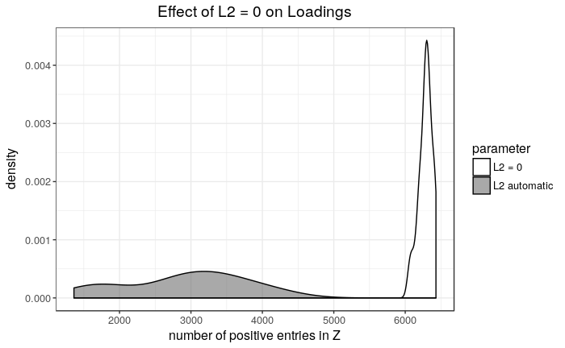

```r
z.positive.df %>%
  ggplot2::ggplot(ggplot2::aes(x = positive_count, group = model_type,
                               fill = model_type)) +
  ggplot2::geom_density(alpha = 0.5) +
  ggplot2::theme_bw() +
  ggplot2::labs(x = "number of positive entries in Z",
                title = "Effect of L2 = 0 on Loadings") +
  ggplot2::theme(plot.title = ggplot2::element_text(hjust = 0.5),
                 text = ggplot2::element_text(size = 12)) +
  ggplot2::guides(fill = ggplot2::guide_legend(title = "parameter")) +
  ggplot2::scale_fill_manual(values = c("#FFFFFF", "#545454"))
```

```r
ggplot2::ggsave(file.path(plot.dir,
                          "L2_effect_on_Z_positive_entries_density.pdf"),
                plot = ggplot2::last_plot())
```